# Students Page

This page exists only to recognize the contributions of past students in this course and to serve as examples and guidance for current students. It is also a tribute to their work and enthusiasm!

Any materials linked on this page are the intellectual property of the students in this course. They may not be reproduced or used in any other manner without express permission of the student involved. Don’t even think about it.

## 2026

### Team 6136

Students in Psych 6136, Winter, 2026

[figure not shown]

### Final Projects

[figure not shown]

- Vanessa Basurto, *Crime in an Analytical World: An Overview of Categorical Data Analysis in Criminology*
- Haley Bernusky, *Latent Class Analysis of Substance Use Patterns: A Tutorial Using NSDUH Data*
- Kiran Bumra, *Clearing Up Confusion: A Categorical Data Analysis Approach to Confusion Matrices*
- Sarah Campbell, *IRT Tutorial: 2PL, Graded Response, and Bifactor Models*
- Gabriel Crone & Naomi Martinez Gutierrez, *Shiny Mosaics: A Shiny Implementation of Interactive Mosaic Displays* – [App](https://fohpsyc.shinyapps.io/psyc6136_app/) | [Writeup](https://gcrone14.github.io/App-Writeup/)
- Kyra Farrelly, *Latent Class Analysis Tutorial: Understanding Cannabis and Other Drug Usage Patterns* | [Video tutorial](https://drive.google.com/file/d/18heWRW27oEO_Lzwx2VBtAGovk_k0-xY1/view?usp=sharing)
- Gavin Klorfine, [*Steps Toward Tidy Categorical Data Analysis in R*](https://friendly.github.io/vcdExtra/articles/a1a-convert-collapse.html)
- Ryley Nathaniel, *Real-Time Categorical Data Analysis*
- Felicia Tassone & Nathaniel Goldstein, *Utilizing Categorical Data Analysis Methods to Quantify Grasping Kinematics* | [Video presentation](https://drive.google.com/file/d/1-QuXonkUZdS_vbCebbFfN4SO490bkcyz/view?usp=sharing)
- Riya Trikha, *Exploring Free Associations*

## 2023

### Team 6136

Students in Psych 6136, Winter, 2023

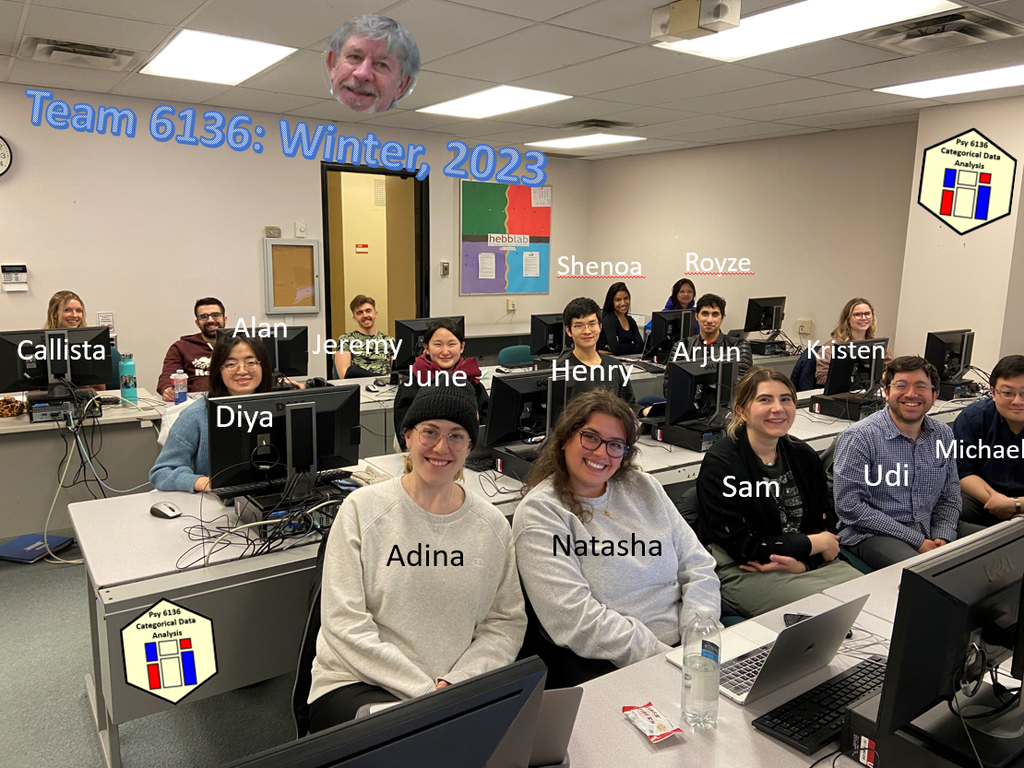

### Final Projects

[figure not shown]

The following projects were submitted in the course. All were of sufficient quality to be forwarded to the nacent *Journal of Categorical Data Analysis*.

- Feldman, Samantha and Levi, Adina, and Baptist-Mohseni, Natasha. *A Broad Review of Categorical Data Analysis in Clinical and Neuropsychology*.
- Forsythe, Jeremy and Forchuk, Callista, and Kian Alan . *Nascent Areas for Categorical Data Analysis: Describing and Applying Latent Class Analysis (LCA) with a focus on Clinical Psychology Research*.
- Lee, Hyeonchung & Kim, Jueun. *Predicting the Stay of Removal Decisions*.
- Lott, Kristen. *Latent Class Analysis for the Social and Behavioural Sciences*.
- Simon, Jenny Royze. *Recent Developments in Categorical Data Analysis*.
- Singh, Arjunvir. *Tidy CDA*.
- Truong, Michael and Alter, Udi. *Throwing a fit: A novel method to properly evaluate goodness-of-fit between discrete distributions*.
- Yang, Dia. *Analysis of Canadian Refugee Board Stay of Removal Decisions*.

*friendly AT yorku DOT ca*

orcid.org/0000-0002-3237-0941